## Lab Worksheet 6

In 1898, Hermon Bumpus, an American biologist working at Brown University, collected data on one of the first examples of natural selection directly observed in nature. Immediately following a bad winter storm, he collected 136 English house sparrows, *Passer domesticus*, and brought them indoors. Of these birds, 64 had died during the storm, but 72 recovered and survived. By comparing measurements of physical traits, Bumpus demonstrated physical differences between the dead and living birds. He interpreted this finding as evidence for natural selection as a result of this storm:

```r
bumpus <- read.csv("http://wilkelab.org/classes/SDS348/data_sets/bumpus_full.csv")
head(bumpus)
```

```
##    Sex   Age Survival Length Wingspread Weight Skull_Length Humerus_Length
## 1 Male Adult    Alive    154        241   24.5         31.2           17.4
## 2 Male Adult    Alive    160        252   26.9         30.8           18.7
## 3 Male Adult    Alive    155        243   26.9         30.6           18.6
## 4 Male Adult    Alive    154        245   24.3         31.7           18.8
## 5 Male Adult    Alive    156        247   24.1         31.5           18.2
## 6 Male Adult    Alive    161        253   26.5         31.8           19.8
##   Femur_Length Tarsus_Length Sternum_Length Skull_Width
## 1         17.0          26.0           21.1        14.9
## 2         18.0          30.0           21.4        15.3
## 3         17.9          29.2           21.5        15.3
## 4         17.5          29.1           21.3        14.8
## 5         17.9          28.7           20.9        14.6
## 6         18.9          29.1           22.7        15.4
```

The data set has three categorical variables (`Sex`, with levels `Male` and `Female`, `Age`, with levels `Adult` and `Young`, and `Survival`, with levels `Alive` and `Dead`) and nine numerical variables that hold various aspects of the birds’ anatomy, such as wingspread, weight, etc.

**Problem 1:** *Make a logistic regression model that can predict survival status from all other predictor variables. (Include the categorical predictors `Sex` and `Age`.) Then do backwards selection, removing the predictors with the highest P value one by one, until you are only left with predictors that have P<0.1. How many and which predictors remain in the final model?*

```r
glm.out.complete <- glm(Survival ~ Sex + Age + Length + Wingspread + Weight + Skull_Length + Humerus_Length + Femur_Length + Tarsus_Length + Sternum_Length + Skull_Width, data=bumpus, family="binomial")
summary(glm.out.complete)
```

```
##
## Call:
## glm(formula = Survival ~ Sex + Age + Length + Wingspread + Weight +
##     Skull_Length + Humerus_Length + Femur_Length + Tarsus_Length +
##     Sternum_Length + Skull_Width, family = "binomial", data = bumpus)
##
## Deviance Residuals:
##     Min       1Q   Median       3Q      Max
## -2.2342  -0.7890  -0.1887   0.7655   2.1927
##
## Coefficients:
##                 Estimate Std. Error z value Pr(>|z|)
## (Intercept)    -10.79812   15.13435  -0.713  0.47555
## SexMale         -1.64710    0.66562  -2.475  0.01334 *
## AgeYoung         0.32973    0.47216   0.698  0.48496
## Length           0.42375    0.10958   3.867  0.00011 ***
## Wingspread      -0.01025    0.08496  -0.121  0.90394
## Weight           0.88472    0.24353   3.633  0.00028 ***
## Skull_Length    -0.46347    0.46141  -1.004  0.31516
## Humerus_Length  -1.66395    0.89997  -1.849  0.06447 .
## Femur_Length     0.09391    0.86933   0.108  0.91397
## Tarsus_Length   -0.25479    0.39646  -0.643  0.52045
## Sternum_Length  -0.67528    0.32942  -2.050  0.04037 *
## Skull_Width     -0.68535    0.76052  -0.901  0.36750
## ---
## Signif. codes:  0 '***' 0.001 '**' 0.01 '*' 0.05 '.' 0.1 ' ' 1
##
## (Dispersion parameter for binomial family taken to be 1)
##
##     Null deviance: 188.07  on 135  degrees of freedom
## Residual deviance: 129.56  on 124  degrees of freedom
## AIC: 153.56
##
## Number of Fisher Scoring iterations: 5
```

```r
# remove Femur_Length
glm.out <- glm(Survival ~ Sex + Age + Length + Wingspread + Weight + Skull_Length + Humerus_Length + Tarsus_Length + Sternum_Length + Skull_Width, data=bumpus, family="binomial")
summary(glm.out)
```

```
##
## Call:
## glm(formula = Survival ~ Sex + Age + Length + Wingspread + Weight +
##     Skull_Length + Humerus_Length + Tarsus_Length + Sternum_Length +
##     Skull_Width, family = "binomial", data = bumpus)
##
## Deviance Residuals:
##     Min       1Q   Median       3Q      Max
## -2.2444  -0.7987  -0.1872   0.7588   2.1838
##
## Coefficients:
##                 Estimate Std. Error z value Pr(>|z|)
## (Intercept)    -10.90876   15.08451  -0.723 0.469571
## SexMale         -1.65241    0.66405  -2.488 0.012833 *
## AgeYoung         0.32606    0.47066   0.693 0.488453
## Length           0.42440    0.10950   3.876 0.000106 ***
## Wingspread      -0.01035    0.08493  -0.122 0.903042
## Weight           0.88092    0.24042   3.664 0.000248 ***
## Skull_Length    -0.45503    0.45461  -1.001 0.316864
## Humerus_Length  -1.61244    0.76223  -2.115 0.034393 *
## Tarsus_Length   -0.23454    0.34926  -0.672 0.501877
## Sternum_Length  -0.67692    0.32915  -2.057 0.039727 *
## Skull_Width     -0.68140    0.75958  -0.897 0.369679
## ---
## Signif. codes:  0 '***' 0.001 '**' 0.01 '*' 0.05 '.' 0.1 ' ' 1
##
## (Dispersion parameter for binomial family taken to be 1)
##
##     Null deviance: 188.07  on 135  degrees of freedom
## Residual deviance: 129.57  on 125  degrees of freedom
## AIC: 151.57
##
## Number of Fisher Scoring iterations: 5
```

```r
# remove Wingspread
glm.out <- glm(Survival ~ Sex + Age + Length + Weight + Skull_Length + Humerus_Length + Tarsus_Length + Sternum_Length + Skull_Width, data=bumpus, family="binomial")
summary(glm.out)
```

```
##
## Call:
## glm(formula = Survival ~ Sex + Age + Length + Weight + Skull_Length +
##     Humerus_Length + Tarsus_Length + Sternum_Length + Skull_Width,
##     family = "binomial", data = bumpus)
##
## Deviance Residuals:
##     Min       1Q   Median       3Q      Max
## -2.2472  -0.7907  -0.1847   0.7602   2.1922
##
## Coefficients:
##                Estimate Std. Error z value Pr(>|z|)
## (Intercept)    -11.7689    13.3246  -0.883 0.377102
## SexMale         -1.6949     0.5657  -2.996 0.002736 **
## AgeYoung         0.3355     0.4641   0.723 0.469700
## Length           0.4197     0.1023   4.102 4.09e-05 ***
## Weight           0.8799     0.2402   3.663 0.000249 ***
## Skull_Length    -0.4491     0.4517  -0.994 0.320046
## Humerus_Length  -1.6458     0.7111  -2.315 0.020637 *
## Tarsus_Length   -0.2429     0.3424  -0.709 0.478129
## Sternum_Length  -0.6833     0.3251  -2.102 0.035534 *
## Skull_Width     -0.6853     0.7583  -0.904 0.366162
## ---
## Signif. codes:  0 '***' 0.001 '**' 0.01 '*' 0.05 '.' 0.1 ' ' 1
##
## (Dispersion parameter for binomial family taken to be 1)
##
##     Null deviance: 188.07  on 135  degrees of freedom
## Residual deviance: 129.59  on 126  degrees of freedom
## AIC: 149.59
##
## Number of Fisher Scoring iterations: 5
```

```r
# remove Tarsus_Length
glm.out <- glm(Survival ~ Sex + Age + Length + Weight + Skull_Length + Humerus_Length + Sternum_Length + Skull_Width, data=bumpus, family="binomial")
summary(glm.out)
```

```
##
## Call:
## glm(formula = Survival ~ Sex + Age + Length + Weight + Skull_Length +
##     Humerus_Length + Sternum_Length + Skull_Width, family = "binomial",
##     data = bumpus)
##
## Deviance Residuals:
##     Min       1Q   Median       3Q      Max
## -2.2465  -0.8113  -0.1847   0.7575   2.1017
##
## Coefficients:
##                Estimate Std. Error z value Pr(>|z|)
## (Intercept)    -10.7332    13.1537  -0.816 0.414509
## SexMale         -1.5723     0.5368  -2.929 0.003403 **
## AgeYoung         0.3565     0.4624   0.771 0.440738
## Length           0.4173     0.1012   4.122 3.76e-05 ***
## Weight           0.8720     0.2393   3.645 0.000268 ***
## Skull_Length    -0.5098     0.4416  -1.154 0.248299
## Humerus_Length  -1.9455     0.5887  -3.305 0.000950 ***
## Sternum_Length  -0.6725     0.3235  -2.079 0.037597 *
## Skull_Width     -0.7033     0.7561  -0.930 0.352291
## ---
## Signif. codes:  0 '***' 0.001 '**' 0.01 '*' 0.05 '.' 0.1 ' ' 1
##
## (Dispersion parameter for binomial family taken to be 1)
##
##     Null deviance: 188.07  on 135  degrees of freedom
## Residual deviance: 130.08  on 127  degrees of freedom
## AIC: 148.08
##
## Number of Fisher Scoring iterations: 5
```

```r
# remove Age
glm.out <- glm(Survival ~ Sex + Length + Weight + Skull_Length + Humerus_Length + Sternum_Length + Skull_Width, data=bumpus, family="binomial")
summary(glm.out)
```

```
##
## Call:
## glm(formula = Survival ~ Sex + Length + Weight + Skull_Length +
##     Humerus_Length + Sternum_Length + Skull_Width, family = "binomial",
##     data = bumpus)
##
## Deviance Residuals:
##     Min       1Q   Median       3Q      Max
## -2.2938  -0.7823  -0.1952   0.7758   2.0455
##
## Coefficients:
##                Estimate Std. Error z value Pr(>|z|)
## (Intercept)    -11.2855    12.9825  -0.869 0.384691
## SexMale         -1.5916     0.5324  -2.990 0.002794 **
## Length           0.4220     0.1009   4.182 2.89e-05 ***
## Weight           0.8556     0.2350   3.641 0.000272 ***
## Skull_Length    -0.5374     0.4378  -1.228 0.219594
## Humerus_Length  -1.9022     0.5836  -3.259 0.001117 **
## Sternum_Length  -0.6851     0.3207  -2.136 0.032643 *
## Skull_Width     -0.6582     0.7511  -0.876 0.380807
## ---
## Signif. codes:  0 '***' 0.001 '**' 0.01 '*' 0.05 '.' 0.1 ' ' 1
##
## (Dispersion parameter for binomial family taken to be 1)
##
##     Null deviance: 188.07  on 135  degrees of freedom
## Residual deviance: 130.68  on 128  degrees of freedom
## AIC: 146.68
##
## Number of Fisher Scoring iterations: 5
```

```r
# remove Skull_Width
glm.out <- glm(Survival ~ Sex + Length + Weight + Skull_Length + Humerus_Length + Sternum_Length, data=bumpus, family="binomial")
summary(glm.out)
```

```
##
## Call:
## glm(formula = Survival ~ Sex + Length + Weight + Skull_Length +
##     Humerus_Length + Sternum_Length, family = "binomial", data = bumpus)
##
## Deviance Residuals:
##     Min       1Q   Median       3Q      Max
## -2.4048  -0.7911  -0.1888   0.7747   1.9636
##
## Coefficients:
##                Estimate Std. Error z value Pr(>|z|)
## (Intercept)    -15.6788    11.9179  -1.316 0.188319
## SexMale         -1.5427     0.5285  -2.919 0.003511 **
## Length           0.4193     0.1011   4.149 3.34e-05 ***
## Weight           0.8319     0.2321   3.584 0.000339 ***
## Skull_Length    -0.6294     0.4228  -1.488 0.136635
## Humerus_Length  -1.9684     0.5770  -3.412 0.000646 ***
## Sternum_Length  -0.7108     0.3205  -2.218 0.026585 *
## ---
## Signif. codes:  0 '***' 0.001 '**' 0.01 '*' 0.05 '.' 0.1 ' ' 1
##
## (Dispersion parameter for binomial family taken to be 1)
##
##     Null deviance: 188.07  on 135  degrees of freedom
## Residual deviance: 131.46  on 129  degrees of freedom
## AIC: 145.46
##
## Number of Fisher Scoring iterations: 5
```

```r
# remove Skull_Length
glm.out.final <- glm(Survival ~ Sex + Length + Weight + Humerus_Length + Sternum_Length, data=bumpus, family="binomial")
summary(glm.out.final)
```

```
##
## Call:
## glm(formula = Survival ~ Sex + Length + Weight + Humerus_Length +
##     Sternum_Length, family = "binomial", data = bumpus)
##
## Deviance Residuals:
##     Min       1Q   Median       3Q      Max
## -2.4921  -0.7678  -0.2155   0.7890   2.0192
##
## Coefficients:
##                 Estimate Std. Error z value Pr(>|z|)
## (Intercept)    -23.15186   10.83789  -2.136 0.032663 *
## SexMale         -1.39306    0.51054  -2.729 0.006360 **
## Length           0.38266    0.09487   4.034 5.49e-05 ***
## Weight           0.76098    0.22248   3.420 0.000625 ***
## Humerus_Length  -2.17650    0.55596  -3.915 9.05e-05 ***
## Sternum_Length  -0.75484    0.31296  -2.412 0.015870 *
## ---
## Signif. codes:  0 '***' 0.001 '**' 0.01 '*' 0.05 '.' 0.1 ' ' 1
##
## (Dispersion parameter for binomial family taken to be 1)
##
##     Null deviance: 188.07  on 135  degrees of freedom
## Residual deviance: 133.72  on 130  degrees of freedom
## AIC: 145.72
##
## Number of Fisher Scoring iterations: 5
```

The final model uses five predictors, `Sex`, `Length`, `Weight`, `Humerus_Length`, and `Sternum_Length`.

**Problem 2:** *Make a plot of the fitted probability as a function of the linear predictor, colored by survival. Make a density plot that shows how the two outcomes are separated by the linear predictor. Interperet your plots in 1-2 sentences. If you had to choose a cut-off value for alive or dead, where would it be?*

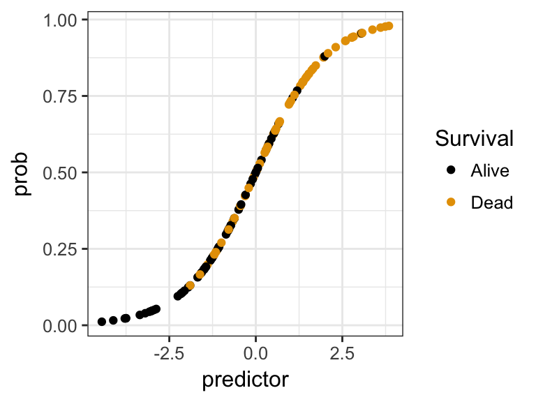

```r
reg_data <- data.frame(predictor=glm.out.final$linear.predictors,
                       prob=glm.out.final$fitted.values,
                       Survival=bumpus$Survival)
ggplot(reg_data, aes(x=predictor, y=prob, color=Survival)) + geom_point() + scale_color_colorblind()
```

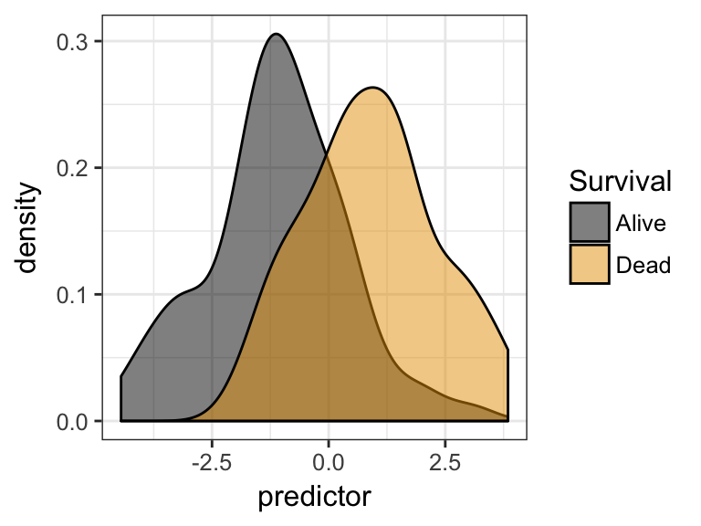

```r
ggplot(reg_data, aes(x=predictor, fill=Survival)) + geom_density(alpha=0.5) + scale_fill_colorblind()
```

Our predictors do not cleanly separate the two survival outcomes alive and dead. There is no single line that can be drawn to separate survival outcomes.

**Problem 3:** *Add rugs to both the top and bottom of the plot above. **BONUS:** Add a curve for the logistic function.*

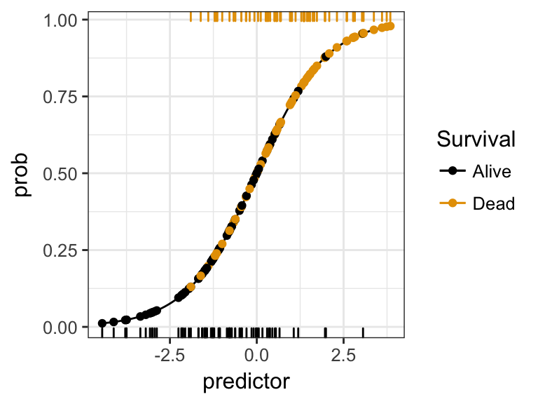

```r
# extract data for alive and dead
alive_data <- filter(reg_data, Survival=="Alive")
dead_data <- filter(reg_data, Survival=="Dead")
# make data frame with logistic function spanning the minimum predictor value to the maximum
predictor <- seq(min(reg_data$predictor), max(reg_data$predictor), 0.1)
prob <- exp(predictor)/(1+exp(predictor))
log_fun_data <- data.frame(predictor, prob)
# plot
ggplot(reg_data , aes(x=predictor, y=prob, color=Survival)) +
    geom_line(data=log_fun_data, color="black") +
    geom_point() +
    geom_rug(data=alive_data, sides='b') +
    geom_rug(data=dead_data, sides='t') +
    scale_color_colorblind()
```